# Beijing Simulated Road Flow

The Beijing simulator reports the entry rate across all lanes of each directed road, in vehicles/hour, once per minute. This example converts one complete day of those records into 288 five-minute Flow frames.

## 1 Set up the example

Run the visible R blocks in order in a fresh interactive R session from this example directory. The setup loads `bdynets` and the local helpers.

`prepare.R` contains this case’s conversion functions.

The expandable code blocks in the following steps show the definitions from the same scripts used by this report. The regular R blocks load those scripts, call the functions in order and show the resulting data. The local `scripts/prepare-input.R` aligns the road and time tables and writes the prepared RDS files. `scripts/street-context.R` reads the local background, and `scripts/report-export.R` saves the prepared data and static maps when export is requested.

```r
library(bdynets)
source("scripts/prepare-input.R", local = TRUE)
source("prepare.R", local = TRUE)
source("scripts/report-export.R", local = TRUE)
source("scripts/street-context.R", local = TRUE)

if (!exists("params", inherits = FALSE)) {
  params <- rmarkdown::yaml_front_matter("beijing-traffic-report.Rmd")$params
}
work_dir <- tempfile("beijing-report-")
dir.create(work_dir)
```

The prepared input guide describes the final drawing object. For other source data, choose the fields, time intervals and conversion rules that fit that data.

## 2 Read the supplied data

Read the supplied simulation-day observations for day 10. The sample has 17,693,280 rows in the original order, covering 12,287 directed pairs and 1,440 source minutes. It retains all 22 source columns. The clock counts minutes since simulation midnight.

The supplied project geometry HTML contains a GeoJSON FeatureCollection in the JavaScript `const network` assignment. Its features give each road’s directed pair, index and longitude–latitude `LineString`. The source manifest lists the two input files and their checksums.

```r
moe_file <- "data/raw/output_LinkTDMOE.csv.gz"
geometry_file <- "data/raw/saturation_dynamic_leaflet_osm_osmgeom.html"

cat(readLines(moe_file, n = 2L), sep = "\n")
```

```
## from_node_id,to_node_id,link_id_from_to,day_no,timestamp_in_min,travel_time_in_min,delay_in_min,link_in_volume_number_of_veh,link_out_volume_number_of_veh,link_volume_in_veh_per_hour_per_lane,link_volume_in_veh_per_hour_for_all_lanes,density_in_veh_per_distance_per_lane,speed,queue_length_percent…
## 1,4106,1->4106,10,0,  1.76,  0.00,  0.00,  0.00,  0.00,  0.00,  0.00,10.00,0.00,0,0,0,0.000000,0.000000,0.000000,0.000000,0.000000,
```

For Flow, the reader keeps `link_id_from_to`, `day_no`, `timestamp_in_min` and `link_volume_in_veh_per_hour_for_all_lanes`. The trailing comma on a source row is preserved in the file. `beijing_read_moe()` reads the supplied file and uses `beijing_moe_table()` to select columns by their original names. `beijing_read_network()` extracts the road properties and coordinates from the HTML.

**Code that reads the CSV fields and the road geometry**

```r
beijing_fields <- c(pair='link_id_from_to',day='day_no',minute='timestamp_in_min',
                    rate='link_volume_in_veh_per_hour_for_all_lanes')

beijing_network <- function(network) {
  if(!identical(network$type,'FeatureCollection')||any(network$features$geometry$type!='LineString'))
    stop('The geometry source must contain directed LineString features.')
  roads<-network$features$properties
  roads$road_id<-as.character(roads$edge_index)
  roads$geometry<-network$features$geometry$coordinates
  if(!nrow(roads)||anyNA(roads$road_id)||anyNA(roads$edge_id)||anyDuplicated(roads$road_id)||
     anyDuplicated(roads$edge_id)||!identical(roads$edge_id,paste(roads$from_node_id,roads$to_node_id,sep='->')))
    stop('Road IDs and directed endpoint pairs must be unique and agree.')
  roads
}

beijing_read_network <- function(geometry_file) {
  lines<-readLines(geometry_file,warn=FALSE,encoding='UTF-8')
  hit<-grep('^[[:space:]]*const network[[:space:]]*=',lines,value=TRUE)
  if(length(hit)!=1L)stop('Geometry file must contain one network FeatureCollection.')
  literal<-sub(';[[:space:]]*$','',sub('^[[:space:]]*const network[[:space:]]*=[[:space:]]*','',hit))
  beijing_network(jsonlite::fromJSON(literal))
}

beijing_moe_table <- function(moe_file, fields) {
  header<-names(read.csv(text=readLines(moe_file,n=1L),check.names=FALSE))
  at<-match(unname(fields),header)
  if(anyNA(at))stop('Required source columns are missing.')
  data.table::fread(moe_file,skip=1L,header=FALSE,select=at,col.names=unname(fields),showProgress=FALSE)
}
```

```r
fields <- beijing_fields
minutes <- beijing_day_minutes
observations <- beijing_read_moe(moe_file, fields)
roads <- beijing_read_network(geometry_file)

example_road <- roads[roads$edge_index == 102L, ]
worked_minutes <- 480:489
example_observations <- observations[
  observations[[fields["pair"]]] == example_road$edge_id &
    observations[[fields["minute"]]] %in% worked_minutes, ]
knitr::kable(example_observations, row.names = FALSE,
             caption = "Worked example: original rates for pair 27 → 6632 at 08:00–08:09")
```

Worked example: original rates for pair 27 → 6632 at 08:00–08:09

| link_id_from_to | day_no | timestamp_in_min | link_volume_in_veh_per_hour_for_all_lanes |
| --- | --- | --- | --- |
| 27->6632 | 10 | 480 | 300 |
| 27->6632 | 10 | 481 | 720 |
| 27->6632 | 10 | 482 | 600 |
| 27->6632 | 10 | 483 | 1080 |
| 27->6632 | 10 | 484 | 540 |
| 27->6632 | 10 | 485 | 360 |
| 27->6632 | 10 | 486 | 1200 |
| 27->6632 | 10 | 487 | 480 |
| 27->6632 | 10 | 488 | 660 |
| 27->6632 | 10 | 489 | 840 |

```r
knitr::kable(example_road[c("edge_index", "edge_id", "from_node_id", "to_node_id", "lanes")],
             row.names = FALSE, caption = "Properties from the matching GeoJSON feature")
```

Properties from the matching GeoJSON feature

| edge_index | edge_id | from_node_id | to_node_id | lanes |
| --- | --- | --- | --- | --- |
| 102 | 27->6632 | 27 | 6632 | 9 |

```r
print(example_road$geometry[[1L]])
```

```
##          [,1]    [,2]
## [1,] 116.5506 39.8482
## [2,] 116.5496 39.8478
```

## 3 Prepare the drawing input

### 3.1 Build the native snapshot and the Flow tables

Join CSV `link_id_from_to` to GeoJSON `edge_id`. The rates for a directed pair fill one row of the native matrix, with columns ordered by source minute. The native object keeps all source pairs and all 1,440 minutes. For the map, the GeoJSON `edge_index` becomes `road_id` and the 11,742 roads with geometry enter the plotted table. The other 545 source pairs have no matching geometry and remain in the native snapshot. The small tables follow one road over ten minutes so the five-minute calculation can be read row by row.

**Code that indexes directed pairs and fills the native minute matrix**

```r
beijing_records <- function(records,roads,expected_minutes,fields=beijing_fields,day=10L) {
  if(!setequal(names(fields),names(beijing_fields))||anyNA(fields)||anyDuplicated(fields)||
     any(!fields%in%names(records)))stop('Map each required MOE role to one distinct source field.')
  records<-as.data.frame(records)[unname(fields[names(beijing_fields)])]
  names(records)<-names(beijing_fields)
  if(!nrow(records)||anyNA(records[c('pair','day')])||!is.numeric(records$minute)||!is.numeric(records$rate)||
     any(!is.finite(records$minute))||any(records$minute!=trunc(records$minute))||
     any(!is.finite(records$rate)|records$rate<0)||any(!nzchar(as.character(records$pair))))
    stop('MOE rows need a directed pair, a whole source minute and a nonnegative finite hourly rate.')
  if(any(records$day!=day))stop('The original-format CSV must contain only the example day.')
  if(!length(expected_minutes)||anyNA(expected_minutes)||any(diff(expected_minutes)!=1))
    stop('Declare the consecutive source-minute domain.')
  if(anyDuplicated(records[c('pair','minute')]))stop('Duplicate directed-pair and minute key.')
  pairs<-unique(as.character(records$pair))
  column<-match(records$minute,expected_minutes)
  if(anyNA(column)||nrow(records)!=length(pairs)*length(expected_minutes))
    stop('Missing or unexpected directed-pair and minute record.')
  values<-matrix(NA_real_,length(pairs),length(expected_minutes))
  values[cbind(match(records$pair,pairs),column)]<-records$rate
  if(any(!roads$edge_id%in%pairs))stop('Source minutes or directed geometry matches are incomplete.')
  list(schema='beijing-native-minute-v1',road_pairs=pairs,minute=expected_minutes,
       minute_rates=values,roads=roads,day_no=day,source_field=unname(fields['rate']),source_columns=fields)
}
```

```r
native <- beijing_records(observations, roads, minutes, fields, day = 10L)
native$source <- basename(c(moe_file, geometry_file))

example_row <- match(example_road$edge_id, native$road_pairs)
example_columns <- match(worked_minutes, native$minute)
knitr::kable(data.frame(
  pair = native$road_pairs[example_row],
  minute = native$minute[example_columns],
  rate = native$minute_rates[example_row, example_columns]
), row.names = FALSE, caption = "Worked example: the same ten rates in the native minute matrix")
```

Worked example: the same ten rates in the native minute matrix

| pair | minute | rate |
| --- | --- | --- |
| 27->6632 | 480 | 300 |
| 27->6632 | 481 | 720 |
| 27->6632 | 482 | 600 |
| 27->6632 | 483 | 1080 |
| 27->6632 | 484 | 540 |
| 27->6632 | 485 | 360 |
| 27->6632 | 486 | 1200 |
| 27->6632 | 487 | 480 |
| 27->6632 | 488 | 660 |
| 27->6632 | 489 | 840 |

The example averages the five observed hourly rates in each interval. For road 102, the first five rates shown above are 300, 720, 600, 1,080 and 540. Their mean is 648 vehicles/hour at the 08:00 frame start. The next five rates give 708 at 08:05. Each output frame starts at the first source minute multiplied by 60. The Flow preparation table pairs every mapped road with every five-minute start from 00:00 through 23:55. `write_beijing_prepared()` writes `source.rds` (the native object), `input.rds` (the Flow preparation tables), and `flow-frames.rds` (the aligned data passed to the map).

**Code that averages five-minute road rates and builds the Flow tables**

```r
beijing_input <- function(native,interval_minutes=5L) {
  if(!identical(native$schema,'beijing-native-minute-v1'))stop('Expected native MOE minute observations.')
  minute<-native$minute;rates<-native$minute_rates;roads<-native$roads
  if(!length(minute)||anyNA(minute)||any(diff(minute)!=1)||ncol(rates)!=length(minute)||
     nrow(rates)!=length(native$road_pairs)||anyDuplicated(native$road_pairs)||
     any(!is.finite(rates)|rates<0))stop('Native MOE IDs, values and minute grid do not agree.')
  if(length(interval_minutes)!=1L||!is.finite(interval_minutes)||interval_minutes<1||
     interval_minutes!=trunc(interval_minutes)||length(minute)%%interval_minutes||minute[1]%%interval_minutes)
    stop('The interval must contain complete aligned source minutes.')
  road_row<-match(roads$edge_id,native$road_pairs)
  if(anyNA(road_row))stop('A directed geometry has no source MOE pair.')
  first<-seq.int(1L,length(minute),by=interval_minutes)
  values<-matrix(0,nrow(roads),length(first))
  for(offset in seq_len(interval_minutes)-1L)values<-values+rates[road_row,first+offset,drop=FALSE]
  values<-values/interval_minutes
  starts<-minute[first]*60
  roads$road_id<-as.character(roads$edge_index)
  flow<-data.frame(road_id=rep(roads$road_id,length(starts)),time=rep(starts,each=nrow(roads)),flow=as.vector(values))
  result <- list(crs='EPSG:4326',roads=roads,flow=flow,times=starts,
    title = 'Beijing simulated entry flow', time_label_format = '%H:%M',
    interval_seconds=rep(interval_minutes*60,length(starts)),unit='vehicles/hour',
    provenance=list(source_fields=if(is.null(native$source_columns))beijing_fields else native$source_columns,day_no=native$day_no,source=native$source,
      source_pairs=length(native$road_pairs),display_roads=nrow(roads),
      excluded_pairs=length(native$road_pairs)-nrow(roads),native_minutes=length(minute),
      native_records=length(rates),retained_minute_records=nrow(roads)*length(minute),
      operation='Arithmetic mean of the minute-sampled hourly entry rates; original example interval is five minutes.'))
  result
}
```

**Code that passes the native object and road tables to the writer**

```r
write_beijing_prepared <- function(native, output_dir, sources, interval_minutes=5L) {
  meanings<-c(edge_index='Source GeoJSON display-road index.',edge_id='Directed source pair, from_node_id -> to_node_id.',
    from_node_id='Source upstream node ID.',to_node_id='Source downstream node ID.',length_km='Source link length in kilometres.',
    lanes='Source all-lane count.',speed_limit='Source speed-limit attribute, unchanged.',link_type_name='Source link-type description.')
  dictionary<-data.frame(table='roads',field=names(meanings),meaning=unname(meanings))
  write_traffic_input(beijing_input(native,interval_minutes),output_dir,
    source_files=sources,native=native,dictionary=dictionary)
}
```

**Code that aligns the drawing matrix and writes all three RDS files**

```r
.prep_road_frames <- function(input) {
  if (!is.list(input) || is.null(names(input)) || anyDuplicated(names(input)))
    stop('Supply a uniquely named list of prepared tables.', call. = FALSE)
  if (any(c('nodes', 'flows', 'od', 'speed') %in% names(input)))
    stop('Flow, Speed and OD inputs are separate formats.', call. = FALSE)
  schema <- input[['schema']]
  if (!is.null(schema) && !identical(schema, 'bdynets-flow-input-v1'))
    stop('Unsupported Flow input schema.', call. = FALSE)
  roads <- input[['roads']]
  observations <- input[['flow']]
  if (!is.data.frame(roads) || !all(c('road_id', 'geometry') %in% names(roads)) ||
      !is.data.frame(observations) || !all(c('road_id', 'time', 'flow') %in% names(observations)))
    stop('Flow tables require roads(road_id, geometry) and flow(road_id, time, flow).', call. = FALSE)
  if (!is.character(roads$road_id) || !is.character(observations$road_id))
    stop('Road IDs must be character in both Flow tables.', call. = FALSE)
  if (is.null(input[['unit']])) stop('Supply the Flow unit.', call. = FALSE)
  input[['schema']] <- NULL
  if (any(!names(input) %in% names(formals(traffic_data))))
    stop('Unknown Flow input fields.', call. = FALSE)
  frames <- do.call(traffic_data, input)
  frames$input_type <- 'flow'
  frames
}

write_traffic_input <- function(input,output_dir,source_files=character(),native=NULL,dictionary=NULL) {
  target<-.prep_destination(output_dir,source_files)
  parent<-dirname(target);dir.create(parent,recursive=TRUE,showWarnings=FALSE)
  lock<-paste0(target,'.preparation-lock')
  if(!dir.create(lock,showWarnings=FALSE))stop('Another preparation is using this output directory.',call.=FALSE)
  on.exit(unlink(lock,recursive=TRUE,expand=FALSE),add=TRUE)
  .prep_destination(output_dir,source_files)
  stage<-tempfile('prepared-data-',tmpdir=parent)
  if(!dir.create(stage))stop('Cannot create preparation staging directory.',call.=FALSE)
  on.exit(unlink(stage,recursive=TRUE,expand=FALSE),add=TRUE)
  info_before<-file.info(source_files)[,c('size','mtime'),drop=FALSE]
  identities<-.prep_sources(source_files)
  object<-input
  object$provenance$preparation_sources <- identities
  road_frames <- .prep_road_frames(object)
  object$schema <- 'bdynets-flow-input-v1'
  tables <- .prep_tables(object)
  dictionary <- .prep_dictionary(tables, object, dictionary)
  na_token<-'\\N'
  strings<-unlist(lapply(tables,function(t)unlist(lapply(t,function(x)if(is.character(x))x else character()),use.names=FALSE)),use.names=FALSE)
  while(na_token%in%strings)na_token<-paste0(na_token,'_')
  saveRDS(object,file.path(stage,'input.rds'),compress='xz',version=3)
  saveRDS(road_frames,file.path(stage,'flow-frames.rds'),compress='xz',version=3)
  if(!is.null(native))saveRDS(native,file.path(stage,'source.rds'),compress='xz',version=3)
  for(name in names(tables)) {
    tab<-as.data.frame(.prep_csv(tables[[name]]),stringsAsFactors=FALSE,optional=TRUE)
    utils::write.csv(tab,file.path(stage,paste0(name,'.csv')),row.names=FALSE,na=na_token,fileEncoding='UTF-8')
  }
  utils::write.csv(dictionary,file.path(stage,'data-dictionary.csv'),row.names=FALSE,na='')
  utils::write.csv(identities,file.path(stage,'source-files.csv'),row.names=FALSE)
  metadata<-object[setdiff(names(object),names(tables))]
  metadata$input_type <- 'flow'
  metadata$csv<-list(missing=na_token,timestamp='POSIXct times are Unix seconds; numeric times retain the declared source clock.',
                     identifiers='Read identifier fields as character.',data='input.rds preserves original types, geometry, timezones and nested provenance.')
  writeLines(jsonlite::toJSON(.tm_provenance_for_json(metadata),auto_unbox=TRUE,null='null',na='null',digits=NA,pretty=TRUE),file.path(stage,'metadata.json'),useBytes=TRUE)
  files<-sort(list.files(stage))
  utils::write.csv(data.frame(file=files,md5=unname(tools::md5sum(file.path(stage,files)))),file.path(stage,'checksums.csv'),row.names=FALSE)
  if(!identical(info_before,file.info(source_files)[,c('size','mtime'),drop=FALSE]))stop('A source changed during preparation.',call.=FALSE)
  .prep_destination(output_dir,source_files)
  if(!file.rename(stage,target))stop('Cannot publish the completed preparation.',call.=FALSE)
  invisible(file.path(target,'input.rds'))
}
```

```r
prepared_dir <- file.path(work_dir, "prepared-data")
input_file <- write_beijing_prepared(native, prepared_dir, c(moe_file, geometry_file))
input <- readRDS(input_file)
flow_frames <- file.path(prepared_dir, "flow-frames.rds")
flow_view <- readRDS(flow_frames)

knitr::kable(data.frame(
  file = c("source.rds", basename(input_file), basename(flow_frames)),
  roads = c(length(native$road_pairs), nrow(input$roads), nrow(flow_view$roads)),
  time_steps = c(length(native$minute), length(input$times), length(flow_view$times)),
  values = c(length(native$minute_rates), nrow(input$flow), length(flow_view$values))
), row.names = FALSE, caption = "Files generated from the complete CSV")
```

Files generated from the complete CSV

| file | roads | time_steps | values |
| --- | --- | --- | --- |
| source.rds | 12287 | 1440 | 17693280 |
| input.rds | 11742 | 288 | 3381696 |
| flow-frames.rds | 11742 | 288 | 3381696 |

```r
worked_starts <- worked_minutes[c(1L, 6L)] * 60
knitr::kable(input$flow[input$flow$road_id == example_road$road_id &
                        input$flow$time %in% worked_starts, ],
             row.names = FALSE, caption = "Worked example: road 102 in input.rds (seconds and vehicles/hour)")
```

Worked example: road 102 in input.rds (seconds and vehicles/hour)

| road_id | time | flow |
| --- | --- | --- |
| 102 | 28800 | 648 |
| 102 | 29100 | 708 |

### 3.2 From the road table to the exact drawing input

The preparation writer takes every frame start in `input.rds` in order and every entry in `roads$road_id` in road-table order. Each observation is placed at `values[match(time, times), match(road_id, roads$road_id)]`. The matrix starts with `NA` cells, so missing road–time observations stay missing and observed zeros remain zero. The resulting object also carries the ordered road geometries, frame widths, units and any prepared events. Preparation saves that object as `flow-frames.rds`. This is the standard drawing input. `input.rds` is the earlier table export for inspecting or reusing the conversion.

```r
observation <- input$flow[input$flow$road_id == example_road$road_id & input$flow$time == worked_starts[1L], ]
row <- match(observation$time, flow_view$times)
column <- match(observation$road_id, flow_view$roads$road_id)
data.frame(road_id = observation$road_id, time = observation$time,
  time_row = row, road_column = column,
  value_in_input_table = observation$flow,
  value_in_drawing_matrix = flow_view$values[row, column])
```

```
##   road_id  time time_row road_column value_in_input_table
## 1     102 28800       97          88                  648
##   value_in_drawing_matrix
## 1                     648
```

```r
data.frame(frame_rows = nrow(flow_view$values),
  road_columns = ncol(flow_view$values), unit = flow_view$unit)
```

```
##   frame_rows road_columns          unit
## 1        288        11742 vehicles/hour
```

## 4 Draw the selected frame

The prepared input contains all 288 five-minute frames. Their starts are seconds since the beginning of the simulation day. The map call selects one frame by its start time and draws the full prepared road extent. Its seven `log1p` colour classes are based on the complete series.

### 4.1 Load the offline background

Load the supplied OpenStreetMap background for the Beijing road extent. The GeoJSON was prepared from OpenFreeMap vector tiles. Its roads, water and place names provide context for the simulator road layer.

```r
street_paths <- "data/basemap-cache/beijing.geojson.gz"
basemap <- if (isTRUE(params$basemap)) read_case_streets(street_paths)
```

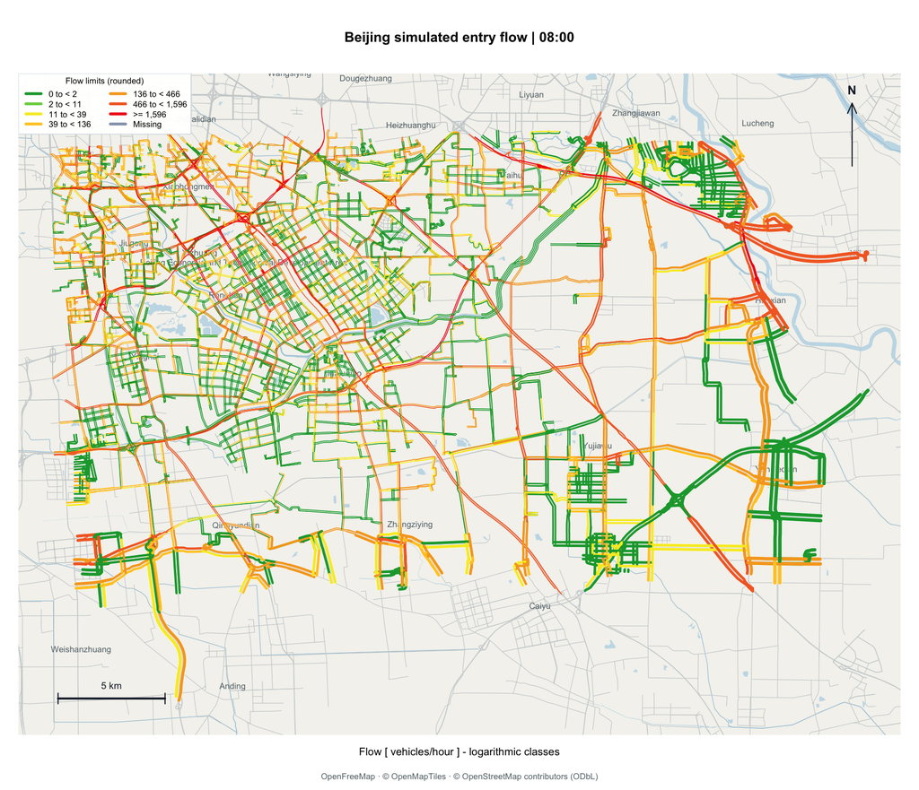

Beijing simulated road entry rate at the selected frame start.

```r
plot_time <- params$plot_time
plotted <- traffic_flow_map(
  flow_frames, time_label = plot_time, basemap = basemap,
  full_extent = TRUE, padding = 0.04
)
```

## 5 Results

The curve shows mean simulated road entry rate over the full day. The dashed line marks the frame shown on the map. Each point is the arithmetic mean of the available road values in that interval. Recorded zeros contribute to the mean.

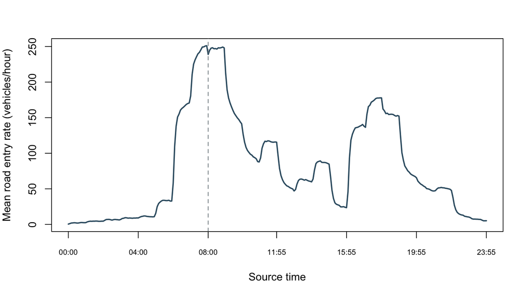

```r
trend <- traffic_trend(flow_view)
plot(trend, metric = "mean", index = plotted$index,
     ylab = "Mean road entry rate (vehicles/hour)")
```

## 6 Export the results

Preparation saves its working files in a temporary directory. The draw calls use the current R graphics device. When running the blocks with `Rscript` and no device open, R can create `Rplots.pdf` in the working directory. To regenerate the report HTML and keep the selected map and complete drawing data, run this command from the example directory:

```bash
Rscript run.R 08:00 --offline --export
```

Replace `08:00` with another prepared frame start to draw that frame. The default destination is a new `output/` directory. To use a different new directory, add `--output-dir NEW_DIRECTORY`.

The command saves the selected map at `output/maps/beijing-flow.png`. `output/prepared-data/flow-frames.rds` contains all prepared frames and can be passed to the same plotting function to draw another frame. The directory also contains `source.rds` and `input.rds`, which record intermediate preparation steps.